# FINAL PROJECT

Ali Ahmed

4/30/2020

Here is a list of the libraries that we may need for this tutorial. dplyr, broom, ggplot2, tidyverse, lubridate, tidyr, png, magick.

```r
library(dplyr)
library(broom)
library(ggplot2)
library(tidyverse)
library(lubridate)
library(tidyr)
library(png)
library(magick)
library(DataExplorer)
```

INTRODUCTION:

In soccer having a potent offense is necessary to secure points and ultimately win championships. While defending is an important facet in the game, I feel that a potent offense is still far more important to the overall success of a soccer club, and in my book, a potent offense can carry a leaky defense.

I will be using player data from the video game FIFA20 and I will examine how many attacking players comprise the top 1500 players in the game. After this, I will look at what specific player stats have the most impact on an attacking player’s overall rating.

BACKGROUND ON THE DATA:

A link to the Kaggle dataset I will be referring to [Found Here.](https://www.kaggle.com/stefanoleone992/fifa-20-complete-player-dataset#players_20.csv) The players_20.csv file contains 18,278 players available in the FIFA 20 career mode. Each player has a host of their skills rated from 1 to 100 (these skills include speed, agility, balance, speed, vision, strength, jumping ability, composure, and things of that nature). The game also keeps track of what club and country each player plays for as well as their position on the pitch. For this tutorial we will be focusing on player positions and their skill ratings club and country are not something that we need to worry about.

The owner of this specific dataset scraped their data from a website called sofifa which is a database that contains all the players available in FIFA 20 and they posted their findings onto Kaggle.

Here is a link to a specific player page on [sofifa.](https://sofifa.com/player/231677) It shows a breakdown of Marcus Rashford’s (striker/winger for Manchester United) skill ratings as well as other pertinent information about him such as his club, country of origin, and current approximate market value.

BACKGROUND ON THE SPORT:

The image below gives a visual representation of the possible position a soccer player may play in over the duration of a match. Now, I will provide a definition for each abbreviation. An ST is a player who plays striker, their purpose is to get in positions where they can score a goal. A CF is a center-forward and they have the same responsibilities as a striker which is to score goals and get in behind the defense. RW/LW are players who play left wing or right wing respectively, these players utilize their speed to provide width during an attack by attacking the wide portions of the field. A CAM is a central attacking midfielder they play behind the wingers and the strikers their main goal is to create goal-scoring opportunities for the wingers, the strikers and anyone who may be in a good attacking spot. A CM is a central midfielder they play in between the defenders and the attackers, their job is to maintain possession of the ball, taking the ball from the opponent, and moving the ball from defense to offense. RM/LM are players who play left midfield or right field they generally have the same responsibilities as a right or left-winger. A CB is center-back their job is to stop the opposing attacking players from getting in behind and scoring goals they are also responsible for covering the central portion of the goal. RB/RWB/LB/LWB is right-back, right-wing back, left-back, and left-wing back respectively, their job is to prevent the wide midfielders and wingers from running rampant on the wing and preventing the ball from coming into the box from their side of the field. Last but not least the GK is the goalkeeper they are the last line of defense and their job is to keep the ball from going into the net.

For the purpose of this tutorial, we will be focusing on the strikers, wingers, and center forwards since they generally have the responsibility of providing the goals.

[figure not shown]

```r
img_path <- "/Users/alinu/Desktop/school/year 5/Spring/CMSC320/soccer_positions.jpg"

img <- image_read(img_path)

plot(img)
```

GATHERING DATA:

First, we need to download and import the data that we will be analyzing. Here is a link to the source of the dataset we will be using for this tutorial: [Kaggle](https://www.kaggle.com/stefanoleone992/fifa-20-complete-player-dataset#players_20.csv)

Download the data and save it as a CSV file.

Here we make sure to add the necessary libraries and load the contents of our data into a data frame.

```r
fifa_players <- read.csv("players_20.csv")
```

Let us check to make sure that the CSV downloaded properly into our data frame by calling head() onto fifa_players. The head() function will return the first 6 rows of our data frame by default which is what we want.

```r
head(fifa_players)
```

|  | sofifa_id | player_url | short_name | long_name | age | dob | height_cm | weight_kg | nationality | club | overall | potential | value_eur | wage_eur | player_positions | preferred_foot | international_reputation | weak_foot | skill_moves | work_rate | body_type | real_face | release_clause_eur | player_tags | team_position | team_jersey_number | loaned_from | joined | contract_valid_until | … |
| --- | --- | --- | --- | --- | --- | --- | --- | --- | --- | --- | --- | --- | --- | --- | --- | --- | --- | --- | --- | --- | --- | --- | --- | --- | --- | --- | --- | --- | --- | --- |
| 1 | 158023 | https://sofifa.com/player/158023/lionel-messi/20/159586 | L. Messi | Lionel Andrés Messi Cuccittini | 32 | 1987-06-24 | 170 | 72 | Argentina | FC Barcelona | 94 | 94 | 95500000 | 565000 | RW, CF, ST | Left | 5 | 4 | 4 | Medium/Low | Messi | Yes | 195800000 | #Dribbler, #Distance Shooter, #Crosser, #FK Specialist, #Acrobat, #Clinical Finisher, #Complete Forward | RW | 10 |  | 2004-07-01 | 2021 | … |
| 2 | 20801 | https://sofifa.com/player/20801/c-ronaldo-dos-santos-aveiro/20/159586 | Cristiano Ronaldo | Cristiano Ronaldo dos Santos Aveiro | 34 | 1985-02-05 | 187 | 83 | Portugal | Juventus | 93 | 93 | 58500000 | 405000 | ST, LW | Right | 5 | 4 | 5 | High/Low | C. Ronaldo | Yes | 96500000 | #Speedster, #Dribbler, #Distance Shooter, #Acrobat, #Clinical Finisher, #Complete Forward | LW | 7 |  | 2018-07-10 | 2022 | … |
| 3 | 190871 | https://sofifa.com/player/190871/neymar-da-silva-santos-jr/20/159586 | Neymar Jr | Neymar da Silva Santos Junior | 27 | 1992-02-05 | 175 | 68 | Brazil | Paris Saint-Germain | 92 | 92 | 105500000 | 290000 | LW, CAM | Right | 5 | 5 | 5 | High/Medium | Neymar | Yes | 195200000 | #Speedster, #Dribbler, #PlaymakerÂ , #Crosser, #FK Specialist, #Acrobat, #Clinical Finisher, #Complete Midfielder, #Complete Forward | CAM | 10 |  | 2017-08-03 | 2022 | … |
| 4 | 200389 | https://sofifa.com/player/200389/jan-oblak/20/159586 | J. Oblak | Jan Oblak | 26 | 1993-01-07 | 188 | 87 | Slovenia | Atlético Madrid | 91 | 93 | 77500000 | 125000 | GK | Right | 3 | 3 | 1 | Medium/Medium | Normal | Yes | 164700000 |  | GK | 13 |  | 2014-07-16 | 2023 | … |
| 5 | 183277 | https://sofifa.com/player/183277/eden-hazard/20/159586 | E. Hazard | Eden Hazard | 28 | 1991-01-07 | 175 | 74 | Belgium | Real Madrid | 91 | 91 | 90000000 | 470000 | LW, CF | Right | 4 | 4 | 4 | High/Medium | Normal | Yes | 184500000 | #Speedster, #Dribbler, #Acrobat | LW | 7 |  | 2019-07-01 | 2024 | … |
| 6 | 192985 | https://sofifa.com/player/192985/kevin-de-bruyne/20/159586 | K. De Bruyne | Kevin De Bruyne | 28 | 1991-06-28 | 181 | 70 | Belgium | Manchester City | 91 | 91 | 90000000 | 370000 | CAM, CM | Right | 4 | 5 | 4 | High/High | Normal | Yes | 166500000 | #Dribbler, #PlaymakerÂ , #Engine, #Distance Shooter, #Crosser, #Complete Midfielder | RCM | 17 |  | 2015-08-30 | 2023 | … |

EXPLORATORY DATA ANALYSIS:

Since we care about the player overalls and their team position let us make sure that our data frame does not contain NA in these specific columns by using is.na() and subset().

```r
new_fifa_players <- subset(fifa_players, !(is.na(fifa_players$overall)))
new_fifa_players <- subset(fifa_players, !(is.na(fifa_players$team_position)))
new_fifa_players <- subset(fifa_players, !(is.na(fifa_players$team_jersey_number)))
head(new_fifa_players)
```

|  | sofifa_id | player_url | short_name | long_name | age | dob | height_cm | weight_kg | nationality | club | overall | potential | value_eur | wage_eur | player_positions | preferred_foot | international_reputation | weak_foot | skill_moves | work_rate | body_type | real_face | release_clause_eur | player_tags | team_position | team_jersey_number | loaned_from | joined | contract_valid_until | … |
| --- | --- | --- | --- | --- | --- | --- | --- | --- | --- | --- | --- | --- | --- | --- | --- | --- | --- | --- | --- | --- | --- | --- | --- | --- | --- | --- | --- | --- | --- | --- |
| 1 | 158023 | https://sofifa.com/player/158023/lionel-messi/20/159586 | L. Messi | Lionel Andrés Messi Cuccittini | 32 | 1987-06-24 | 170 | 72 | Argentina | FC Barcelona | 94 | 94 | 95500000 | 565000 | RW, CF, ST | Left | 5 | 4 | 4 | Medium/Low | Messi | Yes | 195800000 | #Dribbler, #Distance Shooter, #Crosser, #FK Specialist, #Acrobat, #Clinical Finisher, #Complete Forward | RW | 10 |  | 2004-07-01 | 2021 | … |
| 2 | 20801 | https://sofifa.com/player/20801/c-ronaldo-dos-santos-aveiro/20/159586 | Cristiano Ronaldo | Cristiano Ronaldo dos Santos Aveiro | 34 | 1985-02-05 | 187 | 83 | Portugal | Juventus | 93 | 93 | 58500000 | 405000 | ST, LW | Right | 5 | 4 | 5 | High/Low | C. Ronaldo | Yes | 96500000 | #Speedster, #Dribbler, #Distance Shooter, #Acrobat, #Clinical Finisher, #Complete Forward | LW | 7 |  | 2018-07-10 | 2022 | … |
| 3 | 190871 | https://sofifa.com/player/190871/neymar-da-silva-santos-jr/20/159586 | Neymar Jr | Neymar da Silva Santos Junior | 27 | 1992-02-05 | 175 | 68 | Brazil | Paris Saint-Germain | 92 | 92 | 105500000 | 290000 | LW, CAM | Right | 5 | 5 | 5 | High/Medium | Neymar | Yes | 195200000 | #Speedster, #Dribbler, #PlaymakerÂ , #Crosser, #FK Specialist, #Acrobat, #Clinical Finisher, #Complete Midfielder, #Complete Forward | CAM | 10 |  | 2017-08-03 | 2022 | … |
| 4 | 200389 | https://sofifa.com/player/200389/jan-oblak/20/159586 | J. Oblak | Jan Oblak | 26 | 1993-01-07 | 188 | 87 | Slovenia | Atlético Madrid | 91 | 93 | 77500000 | 125000 | GK | Right | 3 | 3 | 1 | Medium/Medium | Normal | Yes | 164700000 |  | GK | 13 |  | 2014-07-16 | 2023 | … |
| 5 | 183277 | https://sofifa.com/player/183277/eden-hazard/20/159586 | E. Hazard | Eden Hazard | 28 | 1991-01-07 | 175 | 74 | Belgium | Real Madrid | 91 | 91 | 90000000 | 470000 | LW, CF | Right | 4 | 4 | 4 | High/Medium | Normal | Yes | 184500000 | #Speedster, #Dribbler, #Acrobat | LW | 7 |  | 2019-07-01 | 2024 | … |
| 6 | 192985 | https://sofifa.com/player/192985/kevin-de-bruyne/20/159586 | K. De Bruyne | Kevin De Bruyne | 28 | 1991-06-28 | 181 | 70 | Belgium | Manchester City | 91 | 91 | 90000000 | 370000 | CAM, CM | Right | 4 | 5 | 4 | High/High | Normal | Yes | 166500000 | #Dribbler, #PlaymakerÂ , #Engine, #Distance Shooter, #Crosser, #Complete Midfielder | RCM | 17 |  | 2015-08-30 | 2023 | … |

Now let us order the data frame by player overall from highest to lowest using order(). Then we get the top 1500 players and put those in another data frame called top1500.

```r
new_fifa_players <- fifa_players[order(-fifa_players$overall),]

top1500 <- head(new_fifa_players, 1500)
head(top1500)
```

|  | sofifa_id | player_url | short_name | long_name | age | dob | height_cm | weight_kg | nationality | club | overall | potential | value_eur | wage_eur | player_positions | preferred_foot | international_reputation | weak_foot | skill_moves | work_rate | body_type | real_face | release_clause_eur | player_tags | team_position | team_jersey_number | loaned_from | joined | contract_valid_until | … |
| --- | --- | --- | --- | --- | --- | --- | --- | --- | --- | --- | --- | --- | --- | --- | --- | --- | --- | --- | --- | --- | --- | --- | --- | --- | --- | --- | --- | --- | --- | --- |
| 1 | 158023 | https://sofifa.com/player/158023/lionel-messi/20/159586 | L. Messi | Lionel Andrés Messi Cuccittini | 32 | 1987-06-24 | 170 | 72 | Argentina | FC Barcelona | 94 | 94 | 95500000 | 565000 | RW, CF, ST | Left | 5 | 4 | 4 | Medium/Low | Messi | Yes | 195800000 | #Dribbler, #Distance Shooter, #Crosser, #FK Specialist, #Acrobat, #Clinical Finisher, #Complete Forward | RW | 10 |  | 2004-07-01 | 2021 | … |
| 2 | 20801 | https://sofifa.com/player/20801/c-ronaldo-dos-santos-aveiro/20/159586 | Cristiano Ronaldo | Cristiano Ronaldo dos Santos Aveiro | 34 | 1985-02-05 | 187 | 83 | Portugal | Juventus | 93 | 93 | 58500000 | 405000 | ST, LW | Right | 5 | 4 | 5 | High/Low | C. Ronaldo | Yes | 96500000 | #Speedster, #Dribbler, #Distance Shooter, #Acrobat, #Clinical Finisher, #Complete Forward | LW | 7 |  | 2018-07-10 | 2022 | … |
| 3 | 190871 | https://sofifa.com/player/190871/neymar-da-silva-santos-jr/20/159586 | Neymar Jr | Neymar da Silva Santos Junior | 27 | 1992-02-05 | 175 | 68 | Brazil | Paris Saint-Germain | 92 | 92 | 105500000 | 290000 | LW, CAM | Right | 5 | 5 | 5 | High/Medium | Neymar | Yes | 195200000 | #Speedster, #Dribbler, #PlaymakerÂ , #Crosser, #FK Specialist, #Acrobat, #Clinical Finisher, #Complete Midfielder, #Complete Forward | CAM | 10 |  | 2017-08-03 | 2022 | … |
| 4 | 200389 | https://sofifa.com/player/200389/jan-oblak/20/159586 | J. Oblak | Jan Oblak | 26 | 1993-01-07 | 188 | 87 | Slovenia | Atlético Madrid | 91 | 93 | 77500000 | 125000 | GK | Right | 3 | 3 | 1 | Medium/Medium | Normal | Yes | 164700000 |  | GK | 13 |  | 2014-07-16 | 2023 | … |
| 5 | 183277 | https://sofifa.com/player/183277/eden-hazard/20/159586 | E. Hazard | Eden Hazard | 28 | 1991-01-07 | 175 | 74 | Belgium | Real Madrid | 91 | 91 | 90000000 | 470000 | LW, CF | Right | 4 | 4 | 4 | High/Medium | Normal | Yes | 184500000 | #Speedster, #Dribbler, #Acrobat | LW | 7 |  | 2019-07-01 | 2024 | … |
| 6 | 192985 | https://sofifa.com/player/192985/kevin-de-bruyne/20/159586 | K. De Bruyne | Kevin De Bruyne | 28 | 1991-06-28 | 181 | 70 | Belgium | Manchester City | 91 | 91 | 90000000 | 370000 | CAM, CM | Right | 4 | 5 | 4 | High/High | Normal | Yes | 166500000 | #Dribbler, #PlaymakerÂ , #Engine, #Distance Shooter, #Crosser, #Complete Midfielder | RCM | 17 |  | 2015-08-30 | 2023 | … |

Now that we have the top 1500 players let us find all of the players who play in the attacking positions and keep track of them. We want to focus on the starters at each club, so we will ignore players who may be attackers but come off the bench or those who are in the reserves.

First, we create a data frame called attacking_players, which keeps track of which players in the top1500 are in fact attackers.

```r
pos_vec <- top1500$team_position
pos_vec <- unique(pos_vec)

attack_pos <- c('ST','LW','LF','RW','RF','CF','RS','LS')
as.vector(attack_pos)
```

```
## [1] "ST" "LW" "LF" "RW" "RF" "CF" "RS" "LS"
```

```r
attacking_players <- top1500

attacking_players$is_attacker <- attacking_players$team_position %in% attack_pos

top1500$is_attacker <- attacking_players$team_position %in% attack_pos

new_fifa_players$is_attacker <- new_fifa_players$team_position %in% attack_pos

attacking_players <- attacking_players %>%
 filter(is_attacker == TRUE)
head(attacking_players)
```

|  | sofifa_id | player_url | short_name | long_name | age | dob | height_cm | weight_kg | nationality | club | overall | potential | value_eur | wage_eur | player_positions | preferred_foot | international_reputation | weak_foot | skill_moves | work_rate | body_type | real_face | release_clause_eur | player_tags | team_position | team_jersey_number | loaned_from | joined | contract_valid_until | … |
| --- | --- | --- | --- | --- | --- | --- | --- | --- | --- | --- | --- | --- | --- | --- | --- | --- | --- | --- | --- | --- | --- | --- | --- | --- | --- | --- | --- | --- | --- | --- |
| 1 | 158023 | https://sofifa.com/player/158023/lionel-messi/20/159586 | L. Messi | Lionel Andrés Messi Cuccittini | 32 | 1987-06-24 | 170 | 72 | Argentina | FC Barcelona | 94 | 94 | 95500000 | 565000 | RW, CF, ST | Left | 5 | 4 | 4 | Medium/Low | Messi | Yes | 195800000 | #Dribbler, #Distance Shooter, #Crosser, #FK Specialist, #Acrobat, #Clinical Finisher, #Complete Forward | RW | 10 |  | 2004-07-01 | 2021 | … |
| 2 | 20801 | https://sofifa.com/player/20801/c-ronaldo-dos-santos-aveiro/20/159586 | Cristiano Ronaldo | Cristiano Ronaldo dos Santos Aveiro | 34 | 1985-02-05 | 187 | 83 | Portugal | Juventus | 93 | 93 | 58500000 | 405000 | ST, LW | Right | 5 | 4 | 5 | High/Low | C. Ronaldo | Yes | 96500000 | #Speedster, #Dribbler, #Distance Shooter, #Acrobat, #Clinical Finisher, #Complete Forward | LW | 7 |  | 2018-07-10 | 2022 | … |
| 3 | 183277 | https://sofifa.com/player/183277/eden-hazard/20/159586 | E. Hazard | Eden Hazard | 28 | 1991-01-07 | 175 | 74 | Belgium | Real Madrid | 91 | 91 | 90000000 | 470000 | LW, CF | Right | 4 | 4 | 4 | High/Medium | Normal | Yes | 184500000 | #Speedster, #Dribbler, #Acrobat | LW | 7 |  | 2019-07-01 | 2024 | … |
| 4 | 209331 | https://sofifa.com/player/209331/mohamed-salah/20/159586 | M. Salah | Mohamed Salah Ghaly | 27 | 1992-06-15 | 175 | 71 | Egypt | Liverpool | 90 | 90 | 80500000 | 240000 | RW, ST | Left | 3 | 3 | 4 | High/Medium | PLAYER_BODY_TYPE_25 | Yes | 148900000 | #Speedster, #Dribbler, #Acrobat, #Clinical Finisher, #Complete Forward | RW | 11 |  | 2017-07-01 | 2023 | … |
| 5 | 231747 | https://sofifa.com/player/231747/kylian-mbappe/20/159586 | K. Mbappé | Kylian Mbappé | 20 | 1998-12-20 | 178 | 73 | France | Paris Saint-Germain | 89 | 95 | 93500000 | 155000 | ST, RW | Right | 3 | 4 | 5 | High/Low | Normal | Yes | 191700000 | #Speedster, #Dribbler, #Acrobat | RW | 7 |  | 2018-07-01 | 2022 | … |
| 6 | 202126 | https://sofifa.com/player/202126/harry-kane/20/159586 | H. Kane | Harry Kane | 25 | 1993-07-28 | 188 | 89 | England | Tottenham Hotspur | 89 | 91 | 83000000 | 220000 | ST | Right | 3 | 4 | 3 | High/High | Normal | Yes | 159800000 | #Engine, #Distance Shooter, #Clinical Finisher | ST | 10 |  | 2010-07-01 | 2024 | … |

Next, we will do a breakdown of the top1500 players to see the ratio between the number of attackers vs non-attackers as well as an itemized view of the number of players at a certain position.

First, let us get a visualization for the total number of attackers vs non-attackers. We will need to use the group_by() function to group the players who are attackers. Then we use ggplot to get a graphical representation of the data. We will use the geom_col function to represent the two groups. Group 1 represents the players who do not play an attacking role for their club and Group 2 represents the players who do play an attacking role for their club.

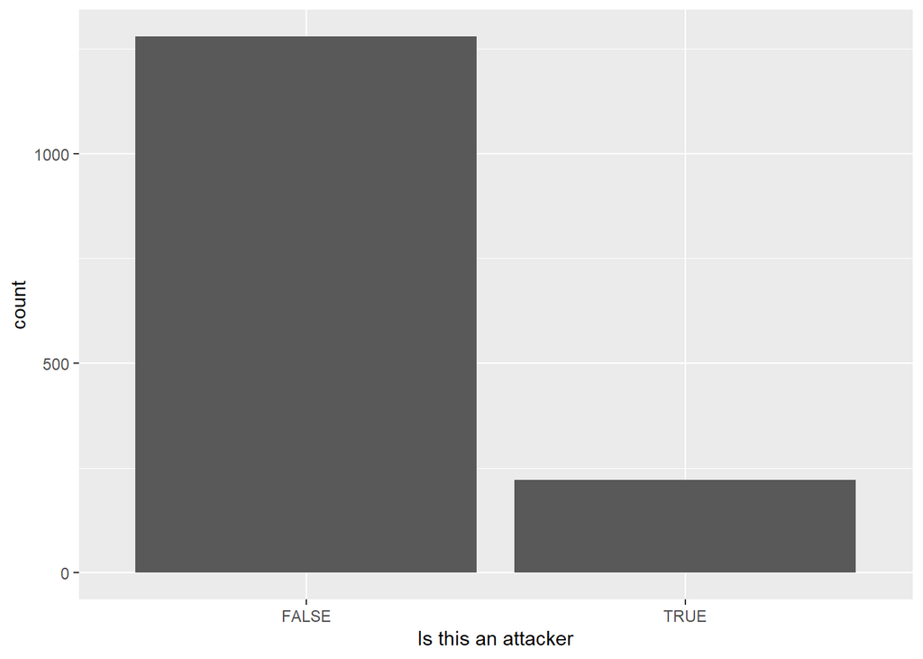

```r
attack_v_nonattack <- top1500 %>%
  group_by(is_attacker) %>%
  count(is_attacker)

attack_v_nonattack %>%
 ggplot(aes(x=is_attacker,y=n,label=is_attacker)) +
        geom_col()+
        xlab("Is this an attacker")+
        ylab("count")
```

Since we broke down the total number of attackers to non-attackers let us break it down even more to a position by position look. To do this we will use the group_by() function to group by position and we will call count on each respective position to get their total.

```r
position_brkdwn <- top1500 %>%
  group_by(team_position) %>%
  count(team_position)

position_brkdwn <- position_brkdwn[order(-position_brkdwn$n),]

head(position_brkdwn)
```

| team_position | n |
| --- | --- |
| SUB | 428 |
| GK | 113 |
| LCB | 88 |
| RCB | 84 |
| ST | 75 |
| RCM | 68 |

When we do a breakdown of all the positions that are in the top1500 we get a couple that should not be included. They are the SUB, RES, and players with no positions so we need to clean that up before we can move on.

Our Solution is to drop the rows that are blank and the rows that contain SUB or RES.

```r
position_brkdwn <-position_brkdwn[!(position_brkdwn$team_position == "" |
                                   position_brkdwn$team_position == "SUB" |
                                   position_brkdwn$team_position == "RES"),]
position_brkdwn <- position_brkdwn[order(-position_brkdwn$n),]

head(position_brkdwn)
```

| team_position | n |
| --- | --- |
| GK | 113 |
| LCB | 88 |
| RCB | 84 |
| ST | 75 |
| RCM | 68 |
| LCM | 66 |

The data frame is now good to go since we dropped the rows that we do not need, so we can now proceed to get a graphical representation of the results from position_brkdwn.

Again we will use ggplot(), make sure to order the data from smallest to largest based on what count() returns. The graph x-axis may look condensed if it is oriented vertically so you can call coor_flip() to orient it horizontally and it will be more readable. To make the graph more visually appealing we will color each column based on a respective position.

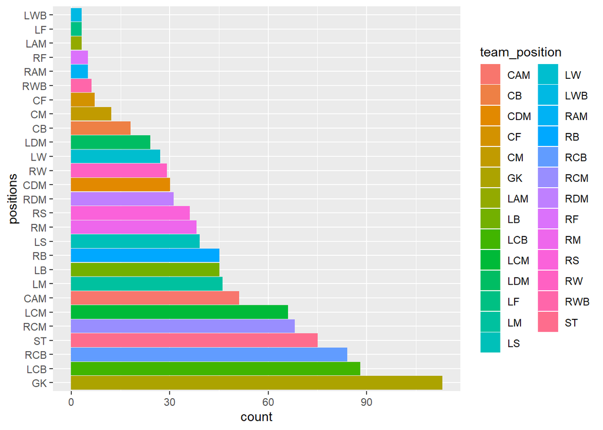

```r
position_brkdwn %>%
  ggplot(aes(x=reorder(team_position,-n),y=n)) +
  geom_col(aes(color= team_position,fill= team_position))  +
  xlab("positions") +
  ylab("count") +
  coord_flip()
```

From the graph, we see that a lot of players in the top 1500 who are starters are goalkeepers, with center backs coming in second and third, and to round out the top 4 we have strikers. Another notable point is that strikers are the only attackers in the top 10. The other 9 spots in the top are distributed between midfielders and defenders.

Since we have a graphical representation of all positions in the top 1500 let us get a graphical visualization of attackers in the top 1500.

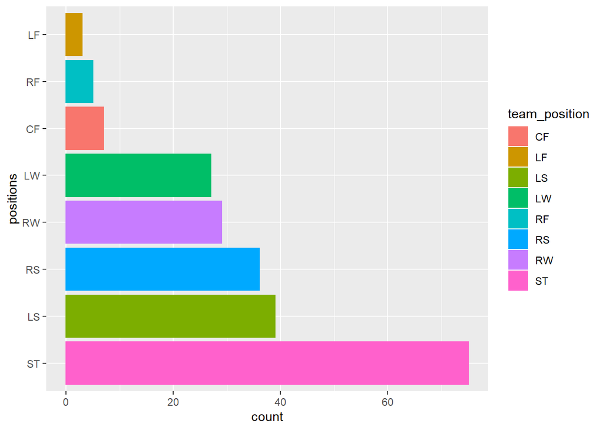

```r
attackers_pos<-attacking_players %>%
  group_by(team_position) %>%
  count(team_position)

attackers_pos %>%
  ggplot(aes(x=reorder(team_position,-n),y=n)) +
  geom_col(aes(color= team_position,fill= team_position))  +
  xlab("positions") +
  ylab("count") +
  coord_flip()
```

From this, we see that strikers of any variation make up the majority of attackers in the top 1500. Wingers come in next with center forwards, left forwards and right forwards rounding out the bottom.

Now that we know the positional breakdown let us group the attackers in the entire dataset by their respective overalls just to see a graphical representation of the distribution of elite attackers.

Let us make a data frame of overall player rating to the total number of them that appear in the FIFA player database. As a side note, we only care about starters, not players who play in the reserves or come off the bench.

```r
attacker_ratings <- new_fifa_players %>%
  filter(is_attacker) %>%
  group_by(overall) %>%
  count(overall)

head(attacker_ratings)
```

| overall | n |
| --- | --- |
| 50 | 1 |
| 51 | 1 |
| 52 | 1 |
| 54 | 2 |
| 55 | 3 |
| 56 | 3 |

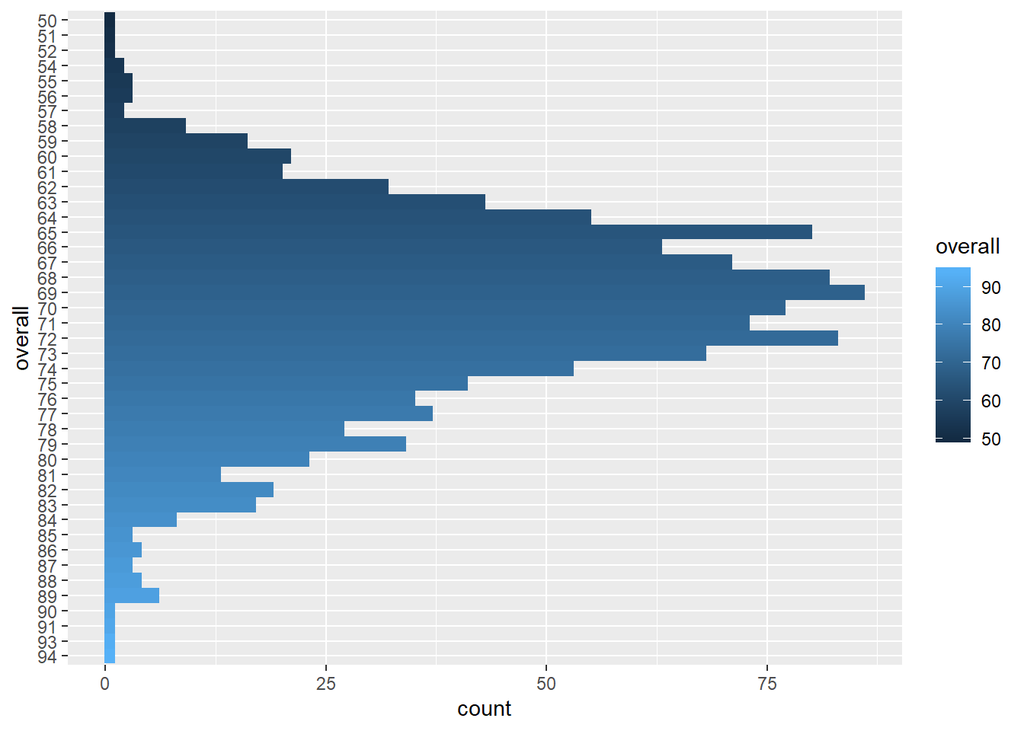

```r
attacker_ratings %>%
  ggplot(aes(x=reorder(overall,-overall),y=n)) +
  geom_col(aes(color= overall,fill= overall))  +
  xlab("overall") +
  ylab("count") +
  coord_flip()
```

From this graph we see a large portion of the attackers fall between a range of 61 and 75. There are very few elite attacking starters.

Now that we have seen a position break down for each position as well as an overall break down of the players, let us now see what skills have a high impact on attacking player’s overall ratings. This way we can see what makes the elite players like Messi and Ronaldo different.

FIFA has broken player skills into 7 major categories (Pace, Defense, Shooting, Goalkeeping, Dribbling, Physical and Passing) each with a varying number of skills.

Here is an image of an actual FIFA card for reference. If you would like to learn more about the image_read() function [go to this website.](https://cran.r-project.org/web/packages/magick/vignettes/intro.html)

[figure not shown]

```r
img_path <- "/Users/alinu/Desktop/school/year 5/Spring/CMSC320/Rashford.png"

img <- image_read(img_path)

plot(img)
```

Let us create a data frame with columns that correlate to each skill as well as some identifiers for each attacking player in the top 1500. Since we are looking at attacking players we can ignore the defensive stats. The last column in each Data Frame will be the average of all of the numerical values of each skill in a specific category.

```r
Pace <- data.frame(attacking_players$short_name,attacking_players$movement_acceleration,
                   attacking_players$movement_sprint_speed,
                   Avg_Pace = ((attacking_players$movement_acceleration+attacking_players$movement_sprint_speed)/2))

Shooting <- data.frame(attacking_players$short_name,attacking_players$mentality_positioning,
                       attacking_players$attacking_finishing,
              attacking_players$power_shot_power, attacking_players$power_long_shots,
              attacking_players$attacking_volleys,attacking_players$mentality_penalties,
              Avg_Shooting = ((attacking_players$mentality_positioning+
                       attacking_players$attacking_finishing+
              attacking_players$power_shot_power+ attacking_players$power_long_shots+
              attacking_players$attacking_volleys+attacking_players$mentality_penalties)/6))


Passing <- data.frame(attacking_players$short_name,attacking_players$mentality_vision,
                      attacking_players$attacking_crossing,
             attacking_players$skill_fk_accuracy, attacking_players$attacking_short_passing,
             attacking_players$skill_long_passing, attacking_players$skill_curve,
             Avg_Passing = ((attacking_players$mentality_vision+
                      attacking_players$attacking_crossing+
             attacking_players$skill_fk_accuracy+ attacking_players$attacking_short_passing+
             attacking_players$skill_long_passing+ attacking_players$skill_curve)/6))


Dribbling <- data.frame(attacking_players$short_name,attacking_players$movement_agility,
                        attacking_players$movement_balance,
               attacking_players$movement_reactions,attacking_players$skill_ball_control,
               attacking_players$dribbling,attacking_players$mentality_composure,
               Avg_Dribbling = ((attacking_players$movement_agility+
                        attacking_players$movement_balance+
               attacking_players$movement_reactions+attacking_players$skill_ball_control+
               attacking_players$dribbling+attacking_players$mentality_composure)/6))

Physical <- data.frame(attacking_players$short_name,attacking_players$power_jumping,
                       attacking_players$power_stamina,attacking_players$power_strength,
                       attacking_players$mentality_aggression,
                       Avg_Physical = ((attacking_players$power_jumping+
                       attacking_players$power_stamina+attacking_players$power_strength+
                       attacking_players$mentality_aggression)/4))

Player_Identifier <- data.frame(attacking_players$short_name,attacking_players$sofifa_id
                                ,attacking_players$team_position,
                                attacking_players$overall)
```

Great, we now have a data frame for each category that may influence attacking players overall. Now let us combine these data frames. To combine the data frames we will be using the merge() function. One we do that we will then make another data frame that only contains the average of each attribute using the data.frame() method.

```r
Merge_attackers <- merge(x=Player_Identifier,y=Pace, all=TRUE)
Merge_attackers <- merge(x=Merge_attackers,y=Shooting, all = TRUE)
Merge_attackers <- merge(x=Merge_attackers,y=Passing, all = TRUE)
Merge_attackers <- merge(x=Merge_attackers,y=Dribbling, all = TRUE)
Merge_attackers <- merge(x=Merge_attackers,y=Physical, all = TRUE)

Merge_attackers <- Merge_attackers[order(-Merge_attackers$attacking_players.overall),]


Merge_attackers_general <- data.frame(Merge_attackers$attacking_players.short_name,
                                      Merge_attackers$attacking_players.overall,
                                      Merge_attackers$attacking_players.team_position,
                                      Merge_attackers$Avg_Pace, Merge_attackers$Avg_Dribbling,
                                      Merge_attackers$Avg_Passing, Merge_attackers$Avg_Physical
                                      , Merge_attackers$Avg_Shooting)
```

CORRELATION MATRIX:

In this section we will create a correlation matrix to see which attributes most closely correlate to an attacking players overall.

If you would like to learn more about how a correlation matrix works visit [Here.](http://www.sthda.com/english/wiki/correlation-matrix-a-quick-start-guide-to-analyze-format-and-visualize-a-correlation-matrix-using-r-software)

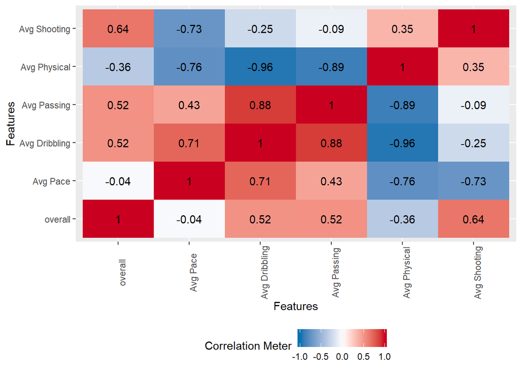

```r
short_name1 <- Merge_attackers_general %>%
  select(2,4:8)

names(short_name1)[names(short_name1) == "Merge_attackers.attacking_players.overall"] <- "overall"

names(short_name1)[names(short_name1) == "Merge_attackers.Avg_Pace"] <- "Avg Pace"

names(short_name1)[names(short_name1) == "Merge_attackers.Avg_Dribbling"] <- "Avg Dribbling"

names(short_name1)[names(short_name1) == "Merge_attackers.Avg_Passing"] <- "Avg Passing"

names(short_name1)[names(short_name1) == "Merge_attackers.Avg_Physical"] <- "Avg Physical"

names(short_name1)[names(short_name1) == "Merge_attackers.Avg_Shooting"] <- "Avg Shooting"

numer = sapply(short_name1,as.numeric)
corr_matrix = cor(numer)
plot_correlation(corr_matrix)
```

From the correlation matrix we see that dribbling passing and shooting have the highest impact on an attacking players overall. In the next section we will create a linear regression and check to see if we get similar results.

LINEAR REGRESSION SECTION:

Now that we have a Data Frame with the average of each category, we will now perform the final steps in this tutorial. We will use a linear regression model to see which stat category has the greatest impact on player overall.

First, create two data frames representing the dependent and independent values, then we use the lm() function to run a linear regression on our data. For more help on how to use lm visit this website for an [example:](http://www.r-tutor.com/elementary-statistics/multiple-linear-regression/significance-test-mlr)

```r
independent_var <- Merge_attackers_general %>%
  select(4:8)

dependent_var <- Merge_attackers_general %>%
  select(2)

names(dependent_var)[names(dependent_var) == "Merge_attackers.attacking_players.overall"] <- "overall"

names(independent_var)[names(independent_var) == "Merge_attackers.Avg_Pace"] <- "Avg Pace"

names(independent_var)[names(independent_var) == "Merge_attackers.Avg_Dribbling"] <- "Avg Dribbling"

names(independent_var)[names(independent_var) == "Merge_attackers.Avg_Passing"] <- "Avg Passing"

names(independent_var)[names(independent_var) == "Merge_attackers.Avg_Physical"] <- "Avg Physical"

names(independent_var)[names(independent_var) == "Merge_attackers.Avg_Shooting"] <- "Avg Shooting"

overall.lm = lm(dependent_var$overall ~ + independent_var$`Avg Pace` +
                  independent_var$`Avg Dribbling` + independent_var$`Avg Passing`
                + independent_var$`Avg Physical` + independent_var$`Avg Shooting`,
                data= Merge_attackers_general)

summary(overall.lm)
```

```
##
## Call:
## lm(formula = dependent_var$overall ~ +independent_var$`Avg Pace` +
##     independent_var$`Avg Dribbling` + independent_var$`Avg Passing` +
##     independent_var$`Avg Physical` + independent_var$`Avg Shooting`,
##     data = Merge_attackers_general)
##
## Residuals:
##     Min      1Q  Median      3Q     Max
## -4.3861 -1.4544  0.0542  1.2683  4.7630
##
## Coefficients:
##                                 Estimate Std. Error t value Pr(>|t|)
## (Intercept)                     16.76920    2.66981   6.281 1.84e-09 ***
## independent_var$`Avg Pace`       0.03692    0.01483   2.490  0.01354 *
## independent_var$`Avg Dribbling`  0.25049    0.03650   6.862 7.13e-11 ***
## independent_var$`Avg Passing`    0.03331    0.02092   1.592  0.11287
## independent_var$`Avg Physical`   0.05917    0.01939   3.052  0.00256 **
## independent_var$`Avg Shooting`   0.45275    0.03312  13.669  < 2e-16 ***
## ---
## Signif. codes:  0 '***' 0.001 '**' 0.01 '*' 0.05 '.' 0.1 ' ' 1
##
## Residual standard error: 1.815 on 215 degrees of freedom
## Multiple R-squared:  0.7498, Adjusted R-squared:  0.744
## F-statistic: 128.9 on 5 and 215 DF,  p-value: < 2.2e-16
```

CONCLUSION:

From this tutorial we were able to isolate the top 1500 soccer players in FIFA 20. We were then able to separate attackers from non-attackers. Finally we were able to create a linear regression model to see which attributes had the most impact on an attacking player’s overall rating.

Thank you for reading this tutorial.

RESOURCES:

http://www.r-tutor.com/elementary-statistics/multiple-linear-regression/significance-test-mlr

http://www.sthda.com/english/wiki/correlation-matrix-a-quick-start-guide-to-analyze-format-and-visualize-a-correlation-matrix-using-r-software

https://cran.r-project.org/web/packages/magick/vignettes/intro.html

https://www.kaggle.com/stefanoleone992/fifa-20-complete-player-dataset#players_20.csv

https://sofifa.com/player/231677

https://www.kaggle.com/stefanoleone992/fifa-20-complete-player-dataset#players_20.csv